# Hypothesis Testing

Ebunoluwa Ajobiewe

November 10, 2020

## R Markdown

**Instructions**

```r
#Change knitr options to save all the graphics in the folder “results” in png format with a resolution of 100dpi.
knitr::opts_chunk$set(echo = TRUE, fig.path = "results", dev = "png", dpi = 100)
#install.packages("agricolae")
#library(agricolae)
#?TukeyHSD
```

**Exercises**

Create a rmarkdown document with the answers to the following:

*Question 1:* For the data InsectSpray, make a table for the number of insects for each spray with the mean, median and standard error. Note: Use knitr::kable(), or a similar function to print the table with its caption.

```r
data("InsectSprays")      #Call default dataset, "InsectSprays"
str(InsectSprays)         #examine dataset to see its contents
```

```
## 'data.frame':    72 obs. of  2 variables:
##  $ count: num  10 7 20 14 14 12 10 23 17 20 ...
##  $ spray: Factor w/ 6 levels "A","B","C","D",..: 1 1 1 1 1 1 1 1 1 1 ...
```

```r
#create empty vectors then make them into a "for" loop
Spray <- character()
Mean <- Median <- Number_of_insect <- Standard_error <- numeric()
for (i in levels(InsectSprays$spray)) {
  Spray <- c(Spray, paste("Spray", i))               #Sprays
  x <- InsectSprays$count[InsectSprays$spray == i ]
  Number_of_insect <- c(Number_of_insect, sum(x))    #Number of Insects
  Mean <- c(Mean, mean(x))                            #Mean
  Median <- c(Median, median(x))                      #Median
  Standard_error <- c(Standard_error, sd(x) / sqrt(length(x)))  #Standard Error
}
```

```r
#make the vectors created into a single data frame
dIS <- data.frame(Spray, Mean, Median, Number_of_insect, Standard_error)
#print a table with a caption
knitr::kable(dIS, caption = "*Table 1. Number of insects for each spray with the mean, median and standard error for the InsectSprays dataframe from base R*")
```

*Table 1. Number of insects for each spray with the mean, median and standard error for the InsectSprays dataframe from base R*

| Spray | Mean | Median | Number_of_insect | Standard_error |
| --- | --- | --- | --- | --- |
| Spray A | 14.500000 | 14.0 | 174 | 1.3623732 |
| Spray B | 15.333333 | 16.5 | 184 | 1.2329647 |
| Spray C | 2.083333 | 1.5 | 25 | 0.5701984 |
| Spray D | 4.916667 | 5.0 | 59 | 0.7225621 |
| Spray E | 3.500000 | 3.0 | 42 | 0.5000000 |
| Spray F | 16.666667 | 15.0 | 200 | 1.7936476 |

*Question 2:* (A)Print a plot to see the differences of counts between sprays. Include a caption explaining the figure. (B)Which type of plot is the one you choose and why?

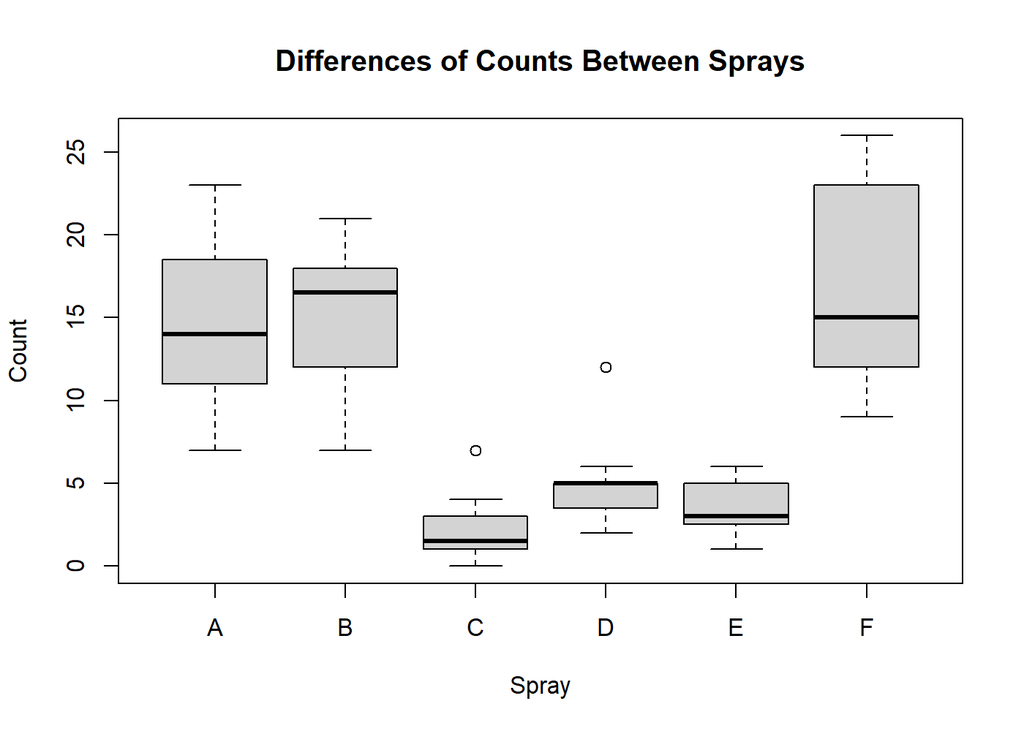

Figure 1:Showing differences of counts between sprays

```r
#(A)
plot(InsectSprays$count ~ InsectSprays$spray, xlab="Spray", ylab="Count")
title(main = "Differences of Counts Between Sprays")
```

```r
cap <- "Figure 1:Showing differences of counts between sprays"
#(B) Boxplot is used here because it shows the median, and allows addition of letters to determine if there are significant differences or not.
```

*Question 3:* Test for differences between sprays using anova and a posthoc comparison and redo the previous plot including the representation of all posthoc differences. Note: for the anova use the command aov() and for the posthoc comparison use the Tukey’s ‘Honest Significant Difference’ method. For this method try the TukeyHSD() and the agricolae::HSD.test() and see the differences.

```r
#one- way anova
Annie <- aov(count ~ spray, data= InsectSprays)
#print the summary of the anova
summary.aov(Annie)
```

```
##             Df Sum Sq Mean Sq F value Pr(>F)
## spray        5   2669   533.8    34.7 <2e-16 ***
## Residuals   66   1015    15.4
## ---
## Signif. codes:  0 '***' 0.001 '**' 0.01 '*' 0.05 '.' 0.1 ' ' 1
```

```r
#using posthoc comparison to see differences
TukeyHSD(Annie)
```

```
##   Tukey multiple comparisons of means
##     95% family-wise confidence level
##
## Fit: aov(formula = count ~ spray, data = InsectSprays)
##
## $spray
##            diff        lwr       upr     p adj
## B-A   0.8333333  -3.866075  5.532742 0.9951810
## C-A -12.4166667 -17.116075 -7.717258 0.0000000
## D-A  -9.5833333 -14.282742 -4.883925 0.0000014
## E-A -11.0000000 -15.699409 -6.300591 0.0000000
## F-A   2.1666667  -2.532742  6.866075 0.7542147
## C-B -13.2500000 -17.949409 -8.550591 0.0000000
## D-B -10.4166667 -15.116075 -5.717258 0.0000002
## E-B -11.8333333 -16.532742 -7.133925 0.0000000
## F-B   1.3333333  -3.366075  6.032742 0.9603075
## D-C   2.8333333  -1.866075  7.532742 0.4920707
## E-C   1.4166667  -3.282742  6.116075 0.9488669
## F-C  14.5833333   9.883925 19.282742 0.0000000
## E-D  -1.4166667  -6.116075  3.282742 0.9488669
## F-D  11.7500000   7.050591 16.449409 0.0000000
## F-E  13.1666667   8.467258 17.866075 0.0000000
```

```r
Honest <- TukeyHSD(Annie)
Ag <- agricolae::HSD.test(Annie, "spray",group=TRUE,console=TRUE)
```

```
##
## Study: Annie ~ "spray"
##
## HSD Test for count
##
## Mean Square Error:  15.38131
##
## spray,  means
##
##       count      std  r Min Max
## A 14.500000 4.719399 12   7  23
## B 15.333333 4.271115 12   7  21
## C  2.083333 1.975225 12   0   7
## D  4.916667 2.503028 12   2  12
## E  3.500000 1.732051 12   1   6
## F 16.666667 6.213378 12   9  26
##
## Alpha: 0.05 ; DF Error: 66
## Critical Value of Studentized Range: 4.150851
##
## Minimun Significant Difference: 4.699409
##
## Treatments with the same letter are not significantly different.
##
##       count groups
## F 16.666667      a
## B 15.333333      a
## A 14.500000      a
## D  4.916667      b
## E  3.500000      b
## C  2.083333      b
```

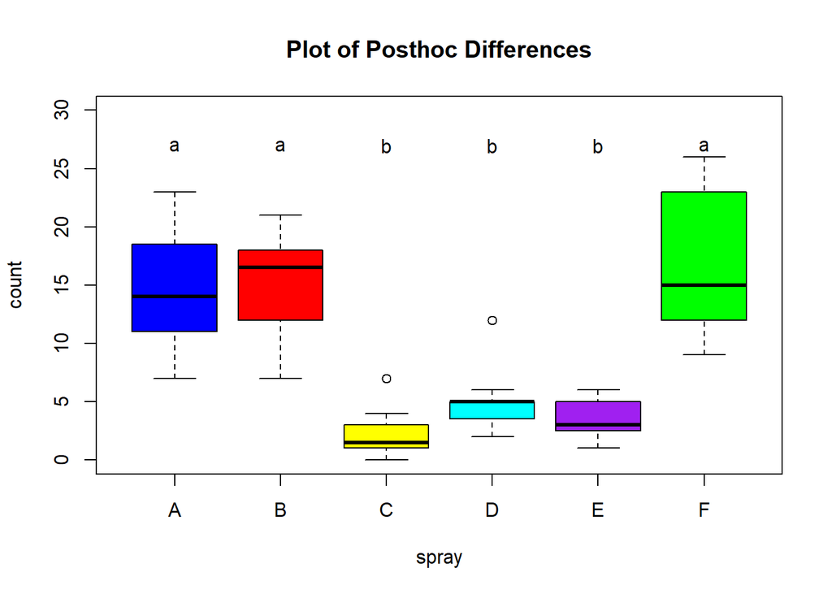

*Figure 2: Showing the Posthoc Differences*

```r
#redoing previous plot with the representation of the posthoc differences and using colors to indicate different sprays
phoc <- boxplot(count~spray, data= InsectSprays, xlabel = "Spray", ylim= c(0,30),ylabel= "Insect count", col= c("Blue", "red", "yellow", "cyan", "purple", "green"))
title(main = "Plot of Posthoc Differences")
cap <- "*Figure 2: Showing the Posthoc Differences*"
#assign letters to the plots to show groups
text(x=1:6, y=27, c("a","a","b","b","b","a"))
```

*Question 4:* Test for differences between sprays using non-parametric Kruskal-Wallis rank sum test. Again, redo the plot with these results. Note: Use agricolae::kruskal().

```r
#using Kruskal-wallis non-parametric test to see differences
KW <- agricolae::kruskal(InsectSprays$count, trt = InsectSprays$spray)
kruskal.test(InsectSprays$count, InsectSprays$spray)
```

```
##
##  Kruskal-Wallis rank sum test
##
## data:  InsectSprays$count and InsectSprays$spray
## Kruskal-Wallis chi-squared = 54.691, df = 5, p-value = 1.511e-10
```

```r
#redoing the plot with KW results
print(KW)
```

```
## $statistics
##      Chisq Df      p.chisq  t.value      MSD
##   54.69134  5 1.510845e-10 1.996564 8.462804
##
## $parameters
##             test p.ajusted             name.t ntr alpha
##   Kruskal-Wallis      none InsectSprays$spray   6  0.05
##
## $means
##   InsectSprays.count     rank      std  r Min Max   Q25  Q50   Q75
## A          14.500000 52.16667 4.719399 12   7  23 11.50 14.0 17.75
## B          15.333333 54.83333 4.271115 12   7  21 12.50 16.5 17.50
## C           2.083333 11.45833 1.975225 12   0   7  1.00  1.5  3.00
## D           4.916667 25.58333 2.503028 12   2  12  3.75  5.0  5.00
## E           3.500000 19.33333 1.732051 12   1   6  2.75  3.0  5.00
## F          16.666667 55.62500 6.213378 12   9  26 12.50 15.0 22.50
##
## $comparison
## NULL
##
## $groups
##   InsectSprays$count groups
## F           55.62500      a
## B           54.83333      a
## A           52.16667      a
## D           25.58333      b
## E           19.33333     bc
## C           11.45833      c
##
## attr(,"class")
## [1] "group"
```

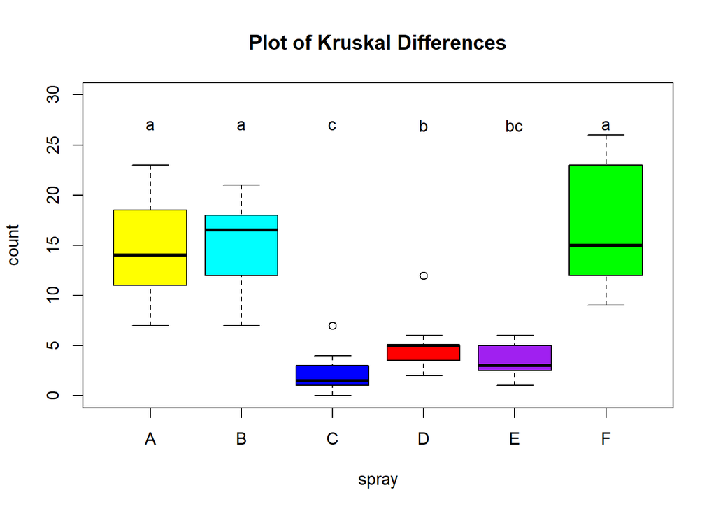

Figure 3: Showing Kruskal Differences

```r
KP <- boxplot(count~spray, data= InsectSprays, xlabel = "Spray", ylim= c(0,30),ylabel= "Insect count", col= c("yellow", "cyan", "Blue", "red", "purple", "green"))
title(main = "Plot of Kruskal Differences")
cap <- "Figure 3: Showing Kruskal Differences"
#assign letters to the plots to show groups
text(x=1:6, y=27, c("a","a","c","b","bc","a"))
```

*Question 5:* Transform count data using sqrt(counts) and redo the anova, the Tukey posthoc comparison and the plot.

```r
#transforming count data
SR <- c(sqrt(InsectSprays$count))
#redoing anova
TransAnnie <- aov(sqrt(count)~spray, data = InsectSprays)
#redoing Tukey posthoc comparison
TransHonest <- TukeyHSD(TransAnnie)
TransAg <- agricolae::HSD.test(TransAnnie,
                               "spray",group=TRUE,console=TRUE)
```

```
##
## Study: TransAnnie ~ "spray"
##
## HSD Test for sqrt(count)
##
## Mean Square Error:  0.3948178
##
## spray,  means
##
##   sqrt.count.       std  r      Min      Max
## A    3.760678 0.6243234 12 2.645751 4.795832
## B    3.876631 0.5768841 12 2.645751 4.582576
## C    1.244857 0.7630074 12 0.000000 2.645751
## D    2.164354 0.5033405 12 1.414214 3.464102
## E    1.809461 0.4963695 12 1.000000 2.449490
## F    4.018617 0.7512773 12 3.000000 5.099020
##
## Alpha: 0.05 ; DF Error: 66
## Critical Value of Studentized Range: 4.150851
##
## Minimun Significant Difference: 0.7529131
##
## Treatments with the same letter are not significantly different.
##
##   sqrt(count) groups
## F    4.018617      a
## B    3.876631      a
## A    3.760678      a
## D    2.164354      b
## E    1.809461     bc
## C    1.244857      c
```

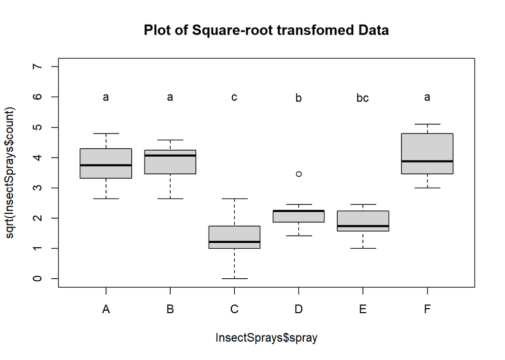

*Figure 4: Figure showing details of sqrt transformed data*

```r
#plotting with the sqrt transformed data
Transphoc <- plot(sqrt(InsectSprays$count)~InsectSprays$spray, ylim= c(0,7))
#assign letters to show groups
text(x=1:6, y=6, c("a","a","c","b","bc","a"))
title(main = "Plot of Square-root transfomed Data")
```

```r
cap <- "*Figure 4: Figure showing details of sqrt transformed data*"
```

*Question 6:* Test for normality of residuals for the two performed anova analyses of points 4 and 6 using shapiro.test() and use plot the anova to see the qqplots and compare them.

*Useful Remark*

```r
#(a)Shapiro tests to check normality on both ANOVAS (Annie & TransAnnie)
shapiro.test(Annie$residuals) #p-value: 0.02226 #Not normally distributed #We want p-value to be more than 0.05
```

```
##
##  Shapiro-Wilk normality test
##
## data:  Annie$residuals
## W = 0.96006, p-value = 0.02226
```

```r
#Test of normality on transformed data
shapiro.test(TransAnnie$residuals) #p-value: 0.6814 #Normally distributed #p-value is more than 0.05
```

```
##
##  Shapiro-Wilk normality test
##
## data:  TransAnnie$residuals
## W = 0.98721, p-value = 0.6814
```

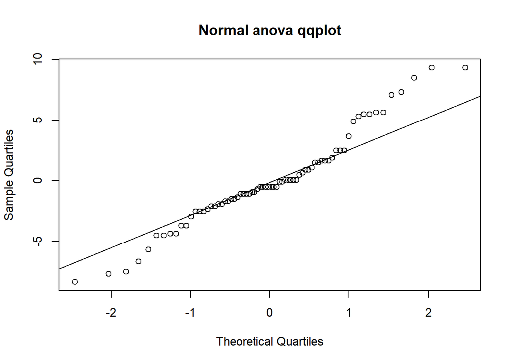

*Figure 5: Showing Normal anova qqplot*

```r
#(b)plotting the anova and checking qqplots to compare them
#qqplot for Annie
qqnorm(Annie$residuals, main = "Normal anova qqplot", xlab = "Theoretical Quartiles", ylab = "Sample Quartiles", plot.it = TRUE, datax = FALSE)
cap <- "*Figure 5: Showing Normal anova qqplot*"
qqline(Annie$residuals, datax = FALSE, distribution = qnorm, probs = c(0.25, 0.75), qtype = 7)
```

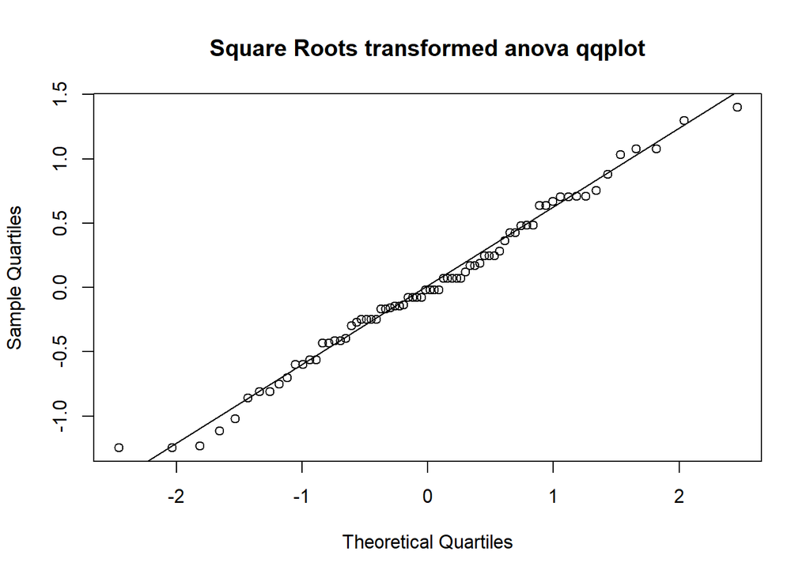

```r
#qqplot for TransAnnnie (i.e sqrt transformed data)
qqnorm(TransAnnie$residuals, main = "Square Roots transformed anova qqplot", xlab = "Theoretical Quartiles", ylab = "Sample Quartiles", plot.it = TRUE, datax = FALSE)
cap <- "*Figure 6: Showing square roots transformed anova qqplot*"
qqline(TransAnnie$residuals, datax = FALSE, distribution = qnorm, probs = c(0.25, 0.75), qtype = 7)
```

*Interpreting qqplots;* qqplots confirms that distribution is actually better in the square root transformed than in the normal anova and it follows the results of the shapiro tests.

*Question 7:*

Which of the previous analysis is the adequate in this case? Why? Is there any difference in the results between the square root transformed ANOVA and the Kruskal-Wallis analyses? Is there any difference in the results between the direct ANOVA and the square root transformed ANOVA? Which ones?

1. In my opinion, the most adequate analysis is the Kruskal- Wallis, since there is no need to make a transformation of the data and it gives same results.In transforming data, it can get confusing and we can loose the meaning of data.

2.There are no differences between the square root transformed ANOVA and the Kruskal-Wallis analysis , both gave the same classification.

3. There are differences between the direct ANOVA and the square root transformed ANOVA . We can see more groups in the sqrt anova and also a mixed group.